# Hyperparameter tuning: an application to real political science research

Three published studies, and what changes when the data are allowed to choose the settings

Author

GOVT 6039 · Discussion Section 2 · Georgy Tarasenko

Published

September 9, 2026

## How to get the files and reproduce everything

Every number, table and figure below is computed when this page is rendered. Nothing is pasted in, so if you change the code you change the document. There are three ways to get to a state where you can do that.

### If you use Git

The section materials live in the course repository under `sections/section02/`.

```bash
git clone https://github.com/ddekadt/cornell-govt-6039.git
cd cornell-govt-6039/sections/section02
quarto render section02-replication.qmd
```

If you would rather not download the whole course repository, check out that one folder:

```bash
git clone --filter=blob:none --sparse https://github.com/ddekadt/cornell-govt-6039.git
cd cornell-govt-6039
git sparse-checkout set sections/section02
cd sections/section02
```

### If you would rather not use Git

Two files are enough. Put them in an empty folder and render:

```bash
curl -O https://raw.githubusercontent.com/ddekadt/cornell-govt-6039/main/sections/section02/section02-replication.qmd
curl -O https://raw.githubusercontent.com/ddekadt/cornell-govt-6039/main/sections/section02/replication.css
quarto render section02-replication.qmd
```

You can also click the **`</> Code`** button at the top right of this page and choose *View Source*, then save what you see as `section02-replication.qmd`. The document downloads its own data, so no data files are needed to start.

### If you are installing from scratch

You need R, Quarto, and two R packages.

1. **R** from [cloud.r-project.org](https://cloud.r-project.org/). Any version from 4.1 onward will do.
2. **Quarto** is bundled with Positron, so if you followed the course setup you already have it. Otherwise install it from [quarto.org](https://quarto.org/docs/get-started/), or run `quarto::quarto_version()` in R to check.
3. **Packages**, from the R console:

```r
install.packages(c("ggplot2", "maps"))
```

`ggplot2` draws every figure. `maps` is used only for the world map in Section 4, and that chunk skips itself with a message if the package is absent. Everything else is base R, including both estimators.

### The data

Two public files are downloaded the first time you render and then cached in the working folder, so the second render works offline. If you prefer to fetch them by hand:

| file | source | size |
| --- | --- | --- |
| `interflex.RData` | [`xuyiqing/interflex`](https://github.com/xuyiqing/interflex/blob/master/data/interflex.RData) | 0.2 MB |
| `vdem.RData` | [`vdeminstitute/vdemdata`](https://github.com/vdeminstitute/vdemdata/blob/master/data/vdem.RData) | 34 MB |

A cold render takes about three minutes, nearly all of it in the cross-validation in Section 4. Chunk caching is on, so later renders finish in seconds; delete the `*_cache/` folder if you want a clean run.

**The estimators are written out rather than called from a package**

`k`-NN appears below as nine lines of base R. That is deliberate. The argument of this section is that you choose `k` and you choose the folds, and both choices are easier to see when the loop is in front of you than when it is an argument to someone else’s function. It is also the estimator from Lecture 3, written the way Lecture 4 wrote it.

# 1 What a hyperparameter is, and why the data cannot pick it for you

Lecture 3 introduced $k$ in $k$-NN and called it a tuning parameter: it governs how much to smooth the fitted function. Lecture 4 gave cross-validation two jobs, model selection and model assessment. Model selection chooses a model’s shape or its tuning parameters. Model assessment asks how good the chosen model is.

This document works through the first job on three published studies, and then shows what the second job costs when the folds are drawn without thinking about the data.

The distinction that organises everything below is between two kinds of quantity in a fitted model. A **parameter** is what the data pick: $\hat\beta = \arg\min_b \mathrm{RSS}(b)$. A **hyperparameter** is what you pick before the data are consulted — $k$, the degree of a polynomial, the number of folds $K$, next week’s $\lambda$, and, as Section 4 argues, the way the folds are constructed.

The data cannot pick the second kind by the same route, because training MSE falls monotonically in flexibility. Minimise it over $k$ and you land on $k = 1$ every time, which is Lecture 3’s high-variance corner. Minimise it over polynomial degree and you take the highest degree available. The choice therefore has to be made on rows the model has not seen, which is the second loop that cross-validation supplies.

| hyperparameter | where you met it | what it controls |
| --- | --- | --- |
| $k$ | lecture 3 | how much to smooth |
| polynomial degree | lecture 4 | how curved $f$ may be |
| $K$ | lecture 4 | bias and variance of the CV estimate itself |
| $\lambda$ | next lecture | how hard to shrink |
| the fold structure | Section 4 | what “out of sample” is taken to mean |

## 1.1 How each study is described before it is analysed

Describing a study carefully before fitting anything is worth the two minutes it costs, and there is a good vocabulary for doing it. Slough and Tyson (2023) build a framework for meta-analysis that turns out to be useful well outside that setting, because it forces you to say what a study is aiming at before you say how it was estimated.

In their Definition 2, a study is a triple $\mathcal{E} = \{m, (\omega', \omega''), \theta\}$:

- The **setting** $\theta$ collects features of the population, such as subject attributes, and features of the environment that bear on the behaviour under investigation. The set of settings $\Theta$ marks the scope conditions of the theory, meaning where the mechanism could plausibly arise at all.
- The **contrast** $(\omega', \omega'')$ is the comparison of substantive interest, most often treatment against control, drawn from a set of potential instruments.
- The **measurement strategy** $m$ says which outcomes are of interest and how they are measured.

Two further terms matter for what follows. A **mechanism** shows itself only through its observable influence, which depends jointly on the measurement strategy and the contrast; it has external validity when it produces the same treatment effect across settings, evaluated at the same contrast and measured the same way. And the **empirical target** $\tau_m(\omega', \omega'' \mid \theta)$ is the quantity the study is actually after, the answer to “what is the effect of $A$ on $B$?”, written in their equation (1) as a difference between functionals of potential outcomes over the units on which the mechanism operates.

The reason to import this vocabulary into a section on tuning is that the empirical target is defined before any estimator is chosen. Flexibility and fold construction are decisions about estimation. Both can quietly move what you end up estimating away from the target you named, and the two studies in Section 2 and Section 3 differ in exactly that respect.

Each study below is introduced with its full citation, the question it asks, and then the five components above, so that by the time an estimator appears you already know what it is supposed to be estimating.

## 1.2 Why these three studies

Simulated data would make the point faster and would make it worse. The claim is not that a badly chosen setting *could* distort a result. It is that these choices are already being made, silently and by convention, in work that has been through peer review, and that is only demonstrable on published studies.

The three are here because they fail in different directions.

- Section 2 is the case where leaving the setting at its default produces a finding. The published model reports an effect that changes sign across the moderator, and the sign turns out to come from the functional form rather than from any municipality in the data.
- Section 3 is the case where choosing the setting honestly **confirms** the published result. That matters more than it sounds. A treatment built only on the first case teaches that checking flexibility overturns findings, which is both wrong and corrosive. The pair teaches that it can go either way, that “stay simple” is a legitimate answer, and that the answer is only available to someone who checked.
- Section 4 moves from a setting you can see to one that nobody names. Everyone knows $k$ is a choice. Almost nobody writes down that the fold structure is one, and here it changes not only the error you report but the model you end up selecting.

The first two share a structure, which is why they come as a pair: same kind of target, same published model, opposite verdicts. The third changes the question from how flexible the estimator should be to what “out of sample” was taken to mean, and that is where the damage is largest.

# 2 A knob that invents a finding: noncitizen suffrage and school spending in Sweden

The failure case: the setting is left at its default, and the model reports something the data do not contain.

## 2.1 Step 1: what Vernby studies, and what the study is aiming at

> Vernby, Kåre. 2013. “Inclusion and Public Policy: Evidence from Sweden’s Introduction of Noncitizen Suffrage.” *American Journal of Political Science* 57(1): 15–29.

**The question.** Sweden extended the right to vote in local elections to resident non-citizens in 1976. Does adding a group to the electorate change what elected officials spend money on? Vernby looks at education spending, the largest municipal budget item that immigrant households draw on heavily, and asks whether municipalities where the newly enfranchised were a larger share of the electorate moved their budgets further.

**The study.**

| component | in this study |
| --- | --- |
| setting $\theta$ | Swedish municipalities around the 1976 reform: decentralised local government with real control over school budgets, and a national franchise change that arrives everywhere at once. Municipalities dif… |
| contrast $(\omega', \omega'')$ | not a binary treatment. The comparison is between municipalities where the newly enfranchised were a larger share of the electorate and those where they were a smaller share, so the contrast is define… |
| measurement strategy $m$ | the change in municipal education spending, `school_diff`. |
| mechanism | electoral incentive: officials facing an electorate that now includes non-citizen residents shift spending toward services those residents use. |
| empirical target $\tau_m(\omega',\omega''\mid\theta)$ | the effect of enfranchisement intensity on school spending **at a given tax base**. |

The last row is the one to hold on to. Because the tax base indexes the setting, the target is not a single number but a function of $\theta$, and the paper’s substantive claim is a claim about the shape of that function. Estimating it is where the tuning problem enters, and Section 3 will show a study with the same structure that comes out differently.

```r
u <- paste0("https://raw.githubusercontent.com/xuyiqing/",
            "interflex/master/data/interflex.RData")
# Download once, then reuse the local copy on later renders.
if (!file.exists("interflex.RData")) download.file(u, "interflex.RData", mode = "wb")
# load() puts several objects into the session at once, named as they were saved; one of them
# is app_vernby2013. This is unlike read.csv(), which returns a single object you assign.
load("interflex.RData")
v <- app_vernby2013
c(municipalities = nrow(v), variables = ncol(v))
```

```
municipalities      variables
           183              9
```

| role | variable |
| --- | --- |
| outcome $Y$ | `school_diff` |
| treatment $D$ | `noncitvotsh` |
| moderator $X$ | `Taxbase2` |

## 2.2 Step 2: what the raw data look like before anything is fitted

```r
# ggplot draws one panel per level of a grouping variable, so the three variables are stacked
# into a single long data frame: one column of values, one column naming the variable.
long <- rbind(
  data.frame(value = v$school_diff,  var = "Y: change in school spending"),
  data.frame(value = v$noncitvotsh,  var = "D: noncitizen share of electorate"),
  data.frame(value = v$Taxbase2,     var = "X: tax base (moderator)"))
# factor() with explicit levels fixes the panel order; without it ggplot sorts alphabetically.
long$var <- factor(long$var, levels = unique(long$var))
ggplot(long, aes(value)) +
  geom_histogram(bins = 28, fill = blu, colour = "white", linewidth = .2) +
  facet_wrap(~ var, scales = "free", nrow = 1) +
  labs(x = NULL, y = "municipalities")
```

[figure not shown]

Figure 1: Distributions of the outcome, the treatment and the moderator across 183 Swedish municipalities. The moderator is bunched and the treatment is skewed, which will matter in Step 4.

```r
# sapply() runs summary() on each of the three columns and returns a matrix of the results;
# t() transposes it so variables are rows, which reads better as a table.
knitr::kable(round(t(sapply(v[, c("school_diff", "noncitvotsh", "Taxbase2")], summary)), 3))
```

|  | Min. | 1st Qu. | Median | Mean | 3rd Qu. | Max. |
| --- | --- | --- | --- | --- | --- | --- |
| school_diff | -0.863 | 0.518 | 0.784 | 0.851 | 1.070 | 4.386 |
| noncitvotsh | 0.003 | 0.011 | 0.021 | 0.030 | 0.040 | 0.128 |
| Taxbase2 | 0.516 | 0.786 | 0.814 | 0.862 | 0.891 | 1.373 |

Two features carry forward. The treatment is skewed: half the municipalities have a non-citizen electorate below 2.1%, and the largest is 12.8%. The moderator is bunched: the middle half of municipalities sit between 0.79 and 0.89, while the range runs out to 1.37. In the language of Step 1, most of the settings we observe are similar to each other, and the settings in the upper tail are few.

```r
# Split the moderator into three groups of equal size. Using quantiles as breakpoints (rather
# than evenly spaced cut points) puts 61 municipalities in each group.
v$bin <- cut(v$Taxbase2,
             breaks = quantile(v$Taxbase2, c(0, 1/3, 2/3, 1)),
             labels = c("low tax base", "middle", "high tax base"),
             include.lowest = TRUE)     # otherwise the single smallest value is left out
ggplot(v, aes(noncitvotsh, school_diff)) +
  geom_point(colour = ink, alpha = .55, size = 1.6) +
  geom_smooth(method = "lm", se = FALSE, colour = acc, linewidth = .8) +
  facet_wrap(~ bin, nrow = 1) +
  labs(x = "noncitizen share of the electorate", y = "change in school spending")
```

[figure not shown]

Figure 2: Change in school spending against noncitizen electorate share, within thirds of the tax base, with a within-panel least squares line. The slope flattens from left to right.

The paper’s story is visible in the raw data: the slope is steepest among low-tax-base municipalities and flattest among high-tax-base ones. What the raw data cannot show is what happens past the right-hand panel, and that is precisely what the published estimate will claim to know.

## 2.3 Step 3: reproducing the published estimate

```r
# In an R formula, a * b is shorthand for a + b + a:b, so this fits both main effects and the
# interaction. The interaction coefficient is the fourth row of the output.
m <- lm(school_diff ~ noncitvotsh * Taxbase2, data = v)
round(summary(m)$coefficients, 3)
```

```
                     Estimate Std. Error t value Pr(>|t|)
(Intercept)             0.256      0.456   0.563    0.574
noncitvotsh            39.938     10.499   3.804    0.000
Taxbase2                0.437      0.526   0.831    0.407
noncitvotsh:Taxbase2  -37.427     11.843  -3.160    0.002
```

```r
b <- coef(m)                        # the four estimated coefficients
s <- summary(m)$coefficients        # the full table, including standard errors and t values

# Five representative values of the moderator at which to report the effect.
qs <- quantile(v$Taxbase2, c(.05, .25, .5, .75, .95))

# In a model with an interaction, the effect of D is not one number: it is
# beta_D + beta_DX * x, evaluated at whatever value x of the moderator you care about.
# Naming coefficients by string rather than position keeps this readable.
lin_me <- b["noncitvotsh"] + b["noncitvotsh:Taxbase2"] * qs
round(lin_me, 1)
```

```
  5%  25%  50%  75%  95%
11.7 10.5  9.5  6.6 -2.7
```

The interaction carries $t = -3.16$, and the implied marginal effect runs from $+11.7$ at the 5th percentile of the tax base to $-2.7$ at the 95th. Read straight off the output, the finding is that enfranchisement raises school spending in poor municipalities and lowers it in rich ones.

## 2.4 Step 4: what the estimate assumes, and where the assumption does its work

The model reports $\widehat{ME}(x) = \hat\beta_D + \hat\beta_{DX}\,x$, a straight line in the moderator. That functional form was fixed before anyone looked at the data, and it is a hyperparameter in everything but name: flexibility, set to its most restrictive value by convention.

A straight line with a negative slope has to cross zero somewhere. It is worth asking where.

```r
# Set beta_D + beta_DX * x = 0 and solve for x to find where the fitted effect changes sign.
# as.numeric() strips the coefficient name so the result prints as a bare number.
cross <- as.numeric(-b["noncitvotsh"] / b["noncitvotsh:Taxbase2"])

# mean() of a TRUE/FALSE vector is the proportion that are TRUE, so this converts the crossing
# point into a percentile of the observed moderator.
c(crosses_zero_at = round(cross, 3),
  percentile_of_moderator = round(100 * mean(v$Taxbase2 < cross), 1),
  municipalities_beyond_it = sum(v$Taxbase2 > cross))
```

```
         crosses_zero_at  percentile_of_moderator municipalities_beyond_it
                   1.067                   89.600                   19.000
```

```r
cuts <- quantile(v$Taxbase2, c(1/3, 2/3))    # the tercile boundaries, drawn as dashed lines
ggplot(v, aes(Taxbase2)) +
  # A shaded rectangle covering the region where the fitted effect is negative. ymax = Inf makes
  # it reach the top of the panel whatever the bar heights turn out to be.
  annotate("rect", xmin = cross, xmax = max(v$Taxbase2) + .02, ymin = 0, ymax = Inf,
           fill = acc, alpha = .10) +
  geom_histogram(bins = 34, fill = blu, colour = "white", linewidth = .2) +
  geom_rug(sides = "b", alpha = .5, colour = ink) +
  geom_vline(xintercept = cuts, linetype = "22", colour = gry) +
  geom_vline(xintercept = cross, colour = acc, linewidth = .8) +
  annotate("text", x = cross, y = Inf, vjust = 1.6, hjust = -0.06, colour = acc, size = 3.9,
           label = sprintf("ME crosses zero at %.2f\n%d of %d municipalities lie beyond",
                           cross, sum(v$Taxbase2 > cross), nrow(v))) +
  labs(x = "tax base (moderator)", y = "municipalities")
```

[figure not shown]

Figure 3: Distribution of the tax base, with the tercile cuts (dashed) and the point at which the fitted marginal effect crosses zero (solid). The shaded region holds 19 of 183 municipalities.

The line crosses zero at 1.07, the 90th percentile of the moderator, and 19 of 183 municipalities lie beyond that point. So the claim that the effect reverses is a claim about the thin upper tail of a bunched distribution.

Put that back into the vocabulary from Step 1. The empirical target is $\tau$ evaluated at a setting $\theta$, and there are almost no observed settings in the region where the sign changes. The linear model does not measure $\tau$ there; it supplies a value by extending a slope fitted where the data are dense. That is a modelling assumption doing the work of a measurement.

## 2.5 Step 5: letting the data set the flexibility, and comparing

The binning estimator cuts the moderator into thirds and estimates the effect separately inside each, imposing no functional form across them. It is the crudest way to let the data choose, which is what makes it a useful check.

```r
# lapply() runs the function once per group and returns a list of one-row data frames;
# do.call(rbind, ...) then stacks that list into a single table. This is the base-R equivalent
# of a group-by. Within each third we fit a plain regression with no interaction, so the slope
# on noncitvotsh is the marginal effect for that group alone.
binest <- do.call(rbind, lapply(levels(v$bin), function(L) {
  z <- v[v$bin == L, ]
  f <- lm(school_diff ~ noncitvotsh, data = z)
  data.frame(third = L, n = nrow(z), xbar = mean(z$Taxbase2),
             ME = coef(f)[2],                        # slope = the effect in this group
             se = summary(f)$coefficients[2, 2])     # its standard error
}))
knitr::kable(binest, digits = 2, row.names = FALSE)
```

| third | n | xbar | ME | se |
| --- | --- | --- | --- | --- |
| low tax base | 61 | 0.77 | 14.10 | 2.96 |
| middle | 61 | 0.82 | 7.07 | 2.66 |
| high tax base | 61 | 1.00 | 2.77 | 2.96 |

[figure not shown]

Figure 4: Marginal effect of noncitizen electorate share across the tax base: the linear interaction (line) against estimates within thirds of the moderator (points, 95% intervals). Both show a decline; only the line changes sign.

At the top of the range the line reports $-2.7$ while the municipalities in that region give $+2.8$ with a standard error of 2.96.

**What survives.** The decline survives. The effect is clearly larger where the tax base is low than where it is high, and the $t = -3.16$ is evidence for that slope. The reversal does not survive. Nothing in these data puts the effect below zero anywhere, and in the region where the line goes negative the estimate is positive and not distinguishable from zero.

The restrictive setting did not simply cost precision. It produced a sign.

# 3 A knob that confirms the published finding: threat and partisan identity

The other outcome: the same check, run the same way, leaves the published finding standing.

## 3.1 Step 1: what Huddy, Mason and Aarøe study, and what the study is aiming at

> Huddy, Leonie, Lilliana Mason, and Lene Aarøe. 2015. “Expressive Partisanship: Campaign Involvement, Political Emotion, and Partisan Identity.” *American Political Science Review* 109(1): 1–17.

**The question.** Is partisanship a running tally of policy agreement, or a social identity? The two accounts predict different emotional responses. If the party is part of who you are, then news that threatens its standing should make you angry, and it should do so more strongly the more central the party is to your sense of self.

**The study.**

| component | in this study |
| --- | --- |
| setting $\theta$ | US partisans in an online survey, in a two-party system where partisanship carries social meaning. The feature of the setting that the argument turns on is the strength of a respondent’s partisan iden… |
| contrast $(\omega', \omega'')$ | randomly assigned exposure to threatening information about the party’s electoral standing, against a non-threatening control. Unlike Section 2, this contrast is binary and under the researchers’ cont… |
| measurement strategy $m$ | a self-reported anger index built from emotion items and scaled to run from 0 to 1. |
| mechanism | identity threat: an attack on a group that is central to the self provokes anger, in proportion to how central the group is. |
| empirical target $\tau_m(\omega',\omega''\mid\theta)$ | the effect of threat on anger **at a given level of partisan identity**. |

Structurally this is the same target as Vernby’s: an effect that is a function of the setting rather than a single number. The interesting difference is empirical rather than conceptual, and Step 2 shows what it is.

```r
h <- app_hma2015                                   # loaded with interflex above
c(n = nrow(h),
  control = sum(h$threat == 0),                    # sum() over a TRUE/FALSE vector counts TRUEs
  treated = sum(h$threat == 1))
```

```
      n control treated
   1482     732     750
```

| role | variable |
| --- | --- |
| outcome $Y$ | `totangry` |
| treatment $D$ | `threat` |
| moderator $X$ | `pidentity` |

## 3.2 Step 2: what the raw data look like before anything is fitted

Two things are worth checking before any model: whether randomisation did its job, and where the moderator has data.

```r
# If assignment was random, the two arms should look alike on a pre-treatment variable.
# A large p-value here is reassuring; it is not a test we hope to "pass" so much as a sanity check.
t.test(pidentity ~ threat, data = h)$p.value
```

```
[1] 0.7770993
```

```r
h$arm <- factor(h$threat, levels = 0:1, labels = c("control", "threat"))  # 0/1 -> readable labels

# Stack the two variables into one long data frame so facet_wrap() can draw them side by side.
# Each row records a value, which arm it came from, and which variable it belongs to.
d_mod <- data.frame(value = h$pidentity, arm = h$arm, var = "X: partisan identity, by arm")
d_out <- data.frame(value = h$totangry,  arm = h$arm, var = "Y: anger index")

ggplot(rbind(d_mod, d_out), aes(value, fill = arm)) +
  # position = "identity" overlays the two arms instead of stacking them
  geom_histogram(bins = 26, position = "identity", alpha = .55, colour = NA) +
  facet_wrap(~ var, scales = "free", nrow = 1) +   # "free" = each panel gets its own axis range
  scale_fill_manual(values = c(gry, acc)) +
  labs(x = NULL, y = "respondents", fill = NULL) +
  theme(legend.position = "bottom")
```

[figure not shown]

Figure 5: Partisan identity by experimental arm (left) and the anger index (right), n = 1,482. The arms overlap throughout the moderator’s range and the outcome piles up at zero.

Randomisation holds: the arms differ on the moderator by 0.003 with $p = 0.78$. More important for what follows, the moderator is supported across its whole range in both arms. Compare Figure 3, where the upper tail held 19 municipalities. Here the empirical target is estimable everywhere we want to report it, which is a reason to expect a different verdict from the same exercise.

The outcome deserves a second look: 27% of respondents report exactly zero anger. A floor that large flattens relationships and rewards heavy smoothing.

```r
# cut() slices a continuous variable into intervals. Using quantile() as the breakpoints makes the
# bins equal in *size* (about 247 respondents each) rather than equal in width.
h$mbin <- cut(h$pidentity,
              breaks = quantile(h$pidentity, seq(0, 1, length.out = 7)),
              include.lowest = TRUE)             # otherwise the single lowest value falls outside

# aggregate() computes a summary of one variable within groups: here, mean anger by bin and arm.
agg <- aggregate(totangry ~ mbin + arm, data = h, FUN = mean)

# tapply() gives the mean of pidentity inside each bin; we use it to place points on the x axis.
# Indexing by as.character(agg$mbin) lines those means up with the rows of `agg`.
agg$mid <- tapply(h$pidentity, h$mbin, mean)[as.character(agg$mbin)]

ggplot(agg, aes(mid, totangry, colour = arm)) +
  geom_line(linewidth = .9) + geom_point(size = 2.4) +
  scale_colour_manual(values = c(gry, acc)) +
  labs(x = "partisan identity (bin means)", y = "mean anger", colour = NULL) +
  theme(legend.position = "bottom")
```

[figure not shown]

Figure 6: Mean anger by arm within six equal-sized bins of partisan identity. The vertical gap between the lines is the marginal effect, before any model is imposed.

The gap between the two lines is the quantity the paper is after. It widens as identity rises, which is the claim, and it widens gently, which the linear model is about to exaggerate.

## 3.3 Step 3: reproducing the published estimate

```r
mh <- lm(totangry ~ threat * pidentity, data = h)  # a * b expands to a + b + a:b
round(summary(mh)$coefficients, 3)
```

```
                 Estimate Std. Error t value Pr(>|t|)
(Intercept)         0.278      0.040   7.025    0.000
threat              0.018      0.055   0.328    0.743
pidentity          -0.032      0.055  -0.581    0.561
threat:pidentity    0.421      0.076   5.506    0.000
```

```r
bh <- coef(mh); sh <- summary(mh)$coefficients     # keep these for the inline numbers below
```

The interaction is $\hat\beta_{DX} = 0.421$ with a standard error of 0.076, so $t = 5.51$: strong, and in the predicted direction.

## 3.4 Step 4: letting cross-validation choose how much to smooth

The tool is Lecture 3’s, applied separately within each experimental arm. Estimate $E[Y \mid X]$ by $k$-NN among control respondents, do the same among treated respondents, and read the marginal effect at $x$ as the gap between the two local averages. Then let 10-fold cross-validation pick $k$ in each arm.

```r
# k-NN for a single predictor, returning one column of predictions per value of k.
#   xtr, ytr : training predictor and outcome
#   xte      : points at which we want predictions
#   ks       : a vector of neighbourhood sizes to try
knn1 <- function(xtr, ytr, xte, ks) {
  # outer(a, b, f) builds a matrix with one entry for every (a, b) pair. Here entry [i, j] is the
  # squared distance between test point i and training point j, so M has one row per test point.
  M <- outer(xte, xtr, function(a, b) (a - b)^2)

  out <- matrix(NA_real_, length(xte), length(ks))   # empty container: test points x values of k

  for (i in seq_along(xte)) {                        # seq_along() = 1, 2, ..., length(xte)
    o <- order(M[i, ])                               # indices of training points, nearest first
    # cumsum(ytr[o]) is the running total of y over neighbours in order of distance, and dividing
    # by 1, 2, 3, ... turns it into the running mean. Element k of that vector is exactly the
    # k-NN prediction, so subsetting by `ks` gets every k we asked for in one pass.
    out[i, ] <- (cumsum(ytr[o]) / seq_along(o))[ks]
  }
  out
}

# 10-fold CV over the same grid of k, following Lecture 4.
cvk1 <- function(x, y, ks, K = 10) {
  set.seed(6039)
  # rep(1:K, length.out = n) gives 1,2,...,K,1,2,... up to n; sample() shuffles it, so every
  # observation gets a fold label and the folds come out nearly equal in size.
  f <- sample(rep(1:K, length.out = length(y)))

  M <- matrix(NA_real_, K, length(ks))               # one row per fold, one column per k
  for (j in 1:K) {
    # Fit on everything except fold j (f != j), predict the held-out fold (f == j), and record
    # the mean squared error for every k at once.
    M[j, ] <- colMeans((y[f == j] - knn1(x[f != j], y[f != j], x[f == j], ks))^2)
  }
  colMeans(M)                                        # average the folds, giving one MSE per k
}

ks <- c(5, 10, 25, 50, 100, 200, 400)

# Run the CV separately in each arm. sapply() applies the function to 0 and then 1 and binds the
# two results into a matrix with one column per arm.
cvtab <- sapply(0:1, function(d) {
  z <- h[h$threat == d, ]
  cvk1(z$pidentity, z$totangry, ks)
})
dimnames(cvtab) <- list(k = ks, arm = c("control", "threat"))
round(cvtab, 4)
```

```
     arm
k     control threat
  5    0.1057 0.1037
  10   0.0996 0.0938
  25   0.0945 0.0872
  50   0.0927 0.0849
  100  0.0921 0.0844
  200  0.0921 0.0835
  400  0.0912 0.0850
```

```r
# which.min() returns the position of the smallest value; ks[...] converts that position back
# into the value of k it corresponds to.
best <- ks[apply(cvtab, 2, which.min)]
setNames(best, c("control arm", "treated arm"))
```

```
control arm treated arm
        400         200
```

Cross-validation asks for $k = 400$ and $k = 200$, out of 732 and 750 observations. The data want heavy smoothing, and the CV table shows the preference is broad rather than knife-edge: the column is nearly flat across the larger values of $k$. Recall from Lecture 3 that as $k$ approaches $n$ the fit approaches the intercept-only model. The data are saying that very little local structure is supported here.

## 3.5 Step 5: three settings of one knob, and three different papers

```r
# A grid of moderator values spanning the 5th to 95th percentile, where we will report effects.
g <- seq(quantile(h$pidentity, .05), quantile(h$pidentity, .95), length.out = 9)

# The marginal effect at each grid point: the treated-arm local average minus the control-arm one.
# knn1() returns a matrix, so [, 1] takes its single column when we pass a single k.
me <- function(k) {
  knn1(h$pidentity[h$threat == 1], h$totangry[h$threat == 1], g, k)[, 1] -
  knn1(h$pidentity[h$threat == 0], h$totangry[h$threat == 0], g, k)[, 1]
}

round(rbind(`linear interaction` = bh["threat"] + bh["threat:pidentity"] * g,
            `k-NN, CV's k`       = me(max(best)),
            `k-NN, k = 5`        = me(5)), 2)
```

```
                   [,1] [,2]  [,3] [,4] [,5] [,6] [,7] [,8] [,9]
linear interaction 0.16 0.19  0.23 0.26 0.30 0.33 0.37 0.40 0.44
k-NN, CV's k       0.25 0.25  0.26 0.28 0.29 0.32 0.37 0.37 0.37
k-NN, k = 5        0.11 0.04 -0.07 0.44 0.36 0.33 0.51 0.73 0.36
```

[figure not shown]

Figure 7: Marginal effect of threat across partisan identity under three settings of the flexibility knob. The rigid setting is steeper than the data support; k = 5 crosses zero on noise; the cross-validated fit lies between them.

| setting of the knob | what you would report |  |
| --- | --- | --- |
| $k = 5$, untuned | the effect is non-monotonic and turns negative | noise |
| degree 1, untuned | the effect rises steeply, 0.16 to 0.44 | an overstated slope |
| $k$ from cross-validation | the effect rises gently, 0.25 to 0.37 | what the data support |

**What survives.** The paper’s claim survives. The effect of threat is positive across the range and larger among strong identifiers. The linear model overstates how much larger, being steeper at both ends than the local averages are, but the direction and the ordering hold.

Two conclusions follow, and the second is the one that usually goes unsaid. First, an untuned knob can manufacture a finding in either direction: $k = 5$ produces a dip below zero that a careless reader could write a paragraph about. Second, tuning here confirms the published result, and that is itself a finding. You are only entitled to say it because you checked.

## 3.6 How often does the flexibility choice change a published conclusion?

Hainmueller, Mummolo and Xu ran this check on 46 interaction effects from 22 articles in the *APSR*, *AJPS*, *Comparative Political Studies*, *International Organization* and the *JOP*, published between 2006 and 2015. The effect changes linearly in the moderator in about 48% of cases. In roughly 70%, you cannot reject the hypothesis that the effect is the same at typical low and typical high values of the moderator.

The method is itself under discussion, which is worth knowing before citing it as settled. Simonsohn (2024), and the companion piece “Dear Political Scientists: Don’t Bin, GAM Instead”, argues that binning is the wrong remedy and that the curve should be modelled with a generalised additive model. Hainmueller, Liu, Liu, Mummolo and Xu (2025) reply that the critique measures against the wrong estimand, that the kernel estimator does recover the conditional marginal effect, and that GAMs suit exploration rather than this task. Both sides agree on the point that matters here: the flexibility is a choice, it has to be made explicitly, and the data have to be allowed to inform it. They disagree about how, which leaves the question open.

# 4 The folds are a hyperparameter too, and drawing them badly selects the wrong model

The setting nobody writes down, and the one that does the most damage when it is wrong.

## 4.1 Step 1: what this exercise asks, and how it differs from the two studies above

> Coppedge, Michael, et al. 2025. *V-Dem Country–Year Dataset v15*. Varieties of Democracy Institute. https://v-dem.net

**The question.** How much of a country’s level of democracy is accounted for by its structural conditions? This is the oldest question in comparative political economy, posed here as a prediction problem rather than a causal one.

**The exercise.** The decomposition fits only partly here, and the gaps are what make it worth writing out.

| component | in this exercise |
| --- | --- |
| setting $\theta$ | a country in a year, from 1960 onward. Countries differ in income, size, resource dependence and region, and these are the features of the setting we use as predictors. |
| contrast $(\omega', \omega'')$ | **none**. Nothing is manipulated and no comparison of treatment against control is defined, so this is not a study in their sense. |
| measurement strategy $m$ | V-Dem’s electoral democracy index `v2x_polyarchy`, which runs 0 to 1 and aggregates expert ratings of suffrage, elected officials, clean elections, and freedom of expression and association. |
| mechanism | modernization: economic development changes the distribution of resources and the costs of repression in ways that favour competitive politics. Here it is a conjecture behind the exercise rather than … |
| target | not $\tau$ but $E[Y \mid X]$: a conditional expectation, not a treatment effect. |

The missing contrast is the point. Without one there is no treatment effect to transport, so external validity in the sense defined above does not apply here. What does carry over is the question their definition is built on: does what we learned in the settings we observed hold in settings we did not?

That question has a direct counterpart in how the folds are drawn. Holding out random country-years asks whether the fitted function carries to unseen *rows* inside countries we have already seen. Holding out whole countries asks whether it carries to unseen *settings*. Those are different questions, they have very different answers here, and only the second is the one anybody actually cares about.

```r
uv <- paste0("https://raw.githubusercontent.com/vdeminstitute/",
             "vdemdata/master/data/vdem.RData")

# The full V-Dem file is 34 MB and has over 4,000 columns, so we download it once, keep the seven
# columns used here, and save that small version. Later renders read the small file and skip the
# download entirely.
if (!file.exists("vdem_slim.rds")) {
  if (!file.exists("vdem.RData")) download.file(uv, "vdem.RData", mode = "wb")
  load("vdem.RData")                                  # creates an object called `vdem`
  saveRDS(vdem[, c("country_name", "year", "v2x_polyarchy", "e_gdppc", "e_pop",
                   "e_total_resources_income_pc", "e_regionpol_6C")], "vdem_slim.rds")
  rm(vdem); gc()                                      # drop the large object and reclaim memory
}
vd <- readRDS("vdem_slim.rds")

vd <- vd[vd$year >= 1960 & vd$year <= 2023, ]
vd <- vd[complete.cases(vd), ]                        # keep rows with no missing value anywhere

# Logs compress long right tails so that a $1,000 difference matters more at low income than high.
# pmax(x, .01) floors the value first, because log(0) is undefined.
vd$lgdp <- log(pmax(vd$e_gdppc, .01))
vd$lpop <- log(pmax(vd$e_pop, .01))
# log1p(x) computes log(1 + x), which is the usual fix when a variable is legitimately zero.
vd$lres <- log1p(pmax(vd$e_total_resources_income_pc, 0))

c(country_years = nrow(vd), countries = length(unique(vd$country_name)),
  from = min(vd$year), to = max(vd$year), var_y = round(var(vd$v2x_polyarchy), 4))
```

```
country_years     countries          from            to         var_y
     6697.000       163.000      1960.000      2006.000         0.081
```

Coverage ends in 2006 because the resource-income series does. The panel is only mildly unbalanced: the median country contributes 47 years.

## 4.2 Step 2: what the data look like, and what the panel structure implies

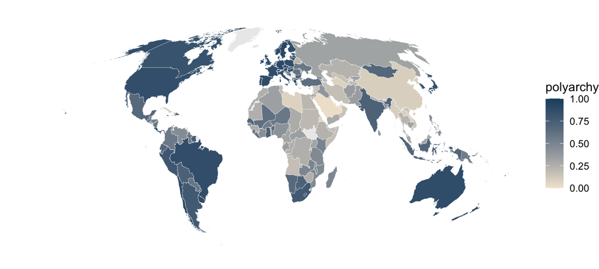

Figure 8: Electoral democracy index in 2006, the last year of the analysis sample. Countries in grey are not in the sample, mostly for missing economic data.

[figure not shown]

Figure 9: Distribution of the electoral democracy index across 6,697 country-years. The mass sits at the two ends.

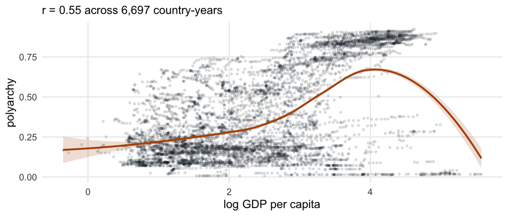

Figure 10: Electoral democracy against log GDP per capita, with a loess fit and its 95% band. The association is positive and loose.

Two things to notice. The association is real but loose, with plenty of poor democracies and rich autocracies. And the smoother turns down at the far right, where its band widens sharply: that is a handful of very rich, very undemocratic country-years, mostly oil exporters, together with the boundary behaviour of a local smoother running out of neighbours. It is the same thin-tail problem as Figure 3, appearing in a flexible estimator rather than a straight line. Neither the line nor the curve should be read out there.

Now the step that decides everything below. The rows are not independent draws. Each country appears up to 47 times, and regime type moves very little from one year to the next.

```r
vd <- vd[order(vd$country_name, vd$year), ]     # sort so each country's years are consecutive

# ave() applies a function within groups and returns a vector the same length as the input.
# Here the function drops the last element and puts NA in front, which shifts the series down by
# one row: each row now carries the *previous year's* value for the same country.
vd$lag1  <- ave(vd$v2x_polyarchy, vd$country_name, FUN = function(z) c(NA, head(z, -1)))
vd$lagyr <- ave(vd$year,          vd$country_name, FUN = function(z) c(NA, head(z, -1)))

# Keep only genuine consecutive pairs: a lag exists, and the years really are one apart (some
# countries have gaps in coverage, and we do not want to treat 1989 and 1994 as adjacent).
ok <- !is.na(vd$lag1) & (vd$year - vd$lagyr == 1)

c(consecutive_pairs = sum(ok),
  correlation_with_own_previous_year = round(cor(vd$v2x_polyarchy[ok], vd$lag1[ok]), 3))
```

```
                 consecutive_pairs correlation_with_own_previous_year
                          6524.000                              0.988
```

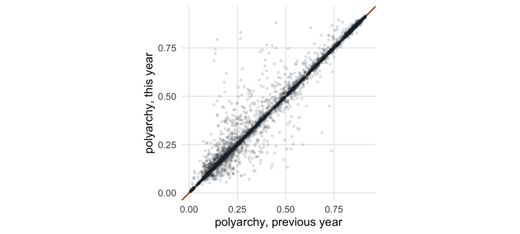

Figure 11: Each country-year’s electoral democracy index against the same country’s value one year earlier, 6,524 consecutive pairs, with the 45-degree line. r = 0.988.

A correlation of 0.988 between a country-year and its own previous year means that any procedure putting Denmark 1994 in the training set and Denmark 1995 in the held-out set is not testing generalisation. It is handing the model a near-copy of the answer. Everything in Steps 4 and 5 follows from this figure.

```r
# Region is categorical, so it enters as a set of 0/1 indicators. model.matrix() builds them;
# "- 1" suppresses the intercept so we get one column per region, and "[, -1]" then drops the
# first column to leave a reference category, which avoids perfect collinearity.
regmat <- model.matrix(~ factor(e_regionpol_6C) - 1, data = vd)[, -1, drop = FALSE]

X    <- cbind(as.matrix(vd[, c("lgdp", "lpop", "lres", "year")]), regmat)
y    <- vd$v2x_polyarchy
ctry <- vd$country_name
dim(X)                                          # rows = country-years, columns = predictors
```

```
[1] 6697    9
```

## 4.3 Step 3: writing the estimator and constructing the folds two ways

Note where the standardisation happens: inside the fold, computed on training rows only. That is Lecture 4’s rule, and it is the easiest one to break by accident.

```r
# k-NN with several predictors, again returning one column per value of k.
knn_all <- function(Xtr, ytr, Xte, ks) {
  # Predictors are on different scales (log income, log population, year), and k-NN measures
  # distance, so an unstandardised variable with a big range would dominate. We centre and scale
  # using the TRAINING rows only, then apply those same numbers to the test rows.
  mu <- colMeans(Xtr); sdv <- apply(Xtr, 2, sd); sdv[sdv == 0] <- 1
  A <- scale(Xtr, mu, sdv)
  B <- scale(Xte, mu, sdv)

  # Squared distance between every test row and every training row, via
  # ||b - a||^2 = ||b||^2 + ||a||^2 - 2 a.b. Written this way it is one matrix multiplication
  # instead of a double loop, which matters at 6,697 rows.
  Dm <- outer(rowSums(B^2), rowSums(A^2), "+") - 2 * B %*% t(A)

  out <- matrix(NA_real_, nrow(B), length(ks))
  for (i in seq_len(nrow(B))) {
    o <- order(Dm[i, ])                          # training rows sorted nearest-first
    out[i, ] <- (cumsum(ytr[o]) / seq_along(o))[ks]   # running means, as in knn1() above
  }
  out
}

# Cross-validation driven by a vector of fold labels, so the same function serves both designs.
cv <- function(fold, ks) {
  M <- matrix(NA_real_, max(fold), length(ks))
  for (j in 1:max(fold)) {
    tr <- fold != j; te <- fold == j             # TRUE/FALSE vectors selecting rows
    M[j, ] <- colMeans((y[te] - knn_all(X[tr, ], y[tr], X[te, ], ks))^2)
  }
  colMeans(M)
}

ks2 <- c(1, 2, 3, 5, 10, 25, 50, 100, 250, 500)
```

```r
# (A) Folds drawn at random over country-years, exactly as in Lecture 4.
set.seed(6039)
fr <- sample(rep(1:10, length.out = nrow(vd)))

# (B) Folds drawn over COUNTRIES. Assign each country to a fold, then give every row of that
# country the same label. match(ctry, uc) finds each row's position in the list of unique
# countries, and indexing the country-level assignment by that position expands it back to rows.
set.seed(6039)
uc <- unique(ctry)
fb <- sample(rep(1:10, length.out = length(uc)))[match(ctry, uc)]

# A diagnostic worth running before any model. tapply() applies a function within groups, so this
# counts how many distinct folds each country's rows are spread across. Under (A) a country's
# rows are scattered; under (B) they are all in one fold, so the count is 1 and the sum is 0.
c(random_folds  = sum(tapply(fr, ctry, function(z) length(unique(z))) > 1),
  blocked_folds = sum(tapply(fb, ctry, function(z) length(unique(z))) > 1))
```

```
 random_folds blocked_folds
          163             0
```

All 163 countries are split across folds under the random design, and none is under blocking. Together with the 0.988 autocorrelation from Step 2, that is enough to predict what follows before a single model is fitted.

```r
A <- cv(fr, ks2)   # random folds
B <- cv(fb, ks2)   # folds drawn over countries
```

## 4.4 Step 4: what random folds report

| k | CV MSE | implied R2 |
| --- | --- | --- |
| 1 | 0.0026 | 0.968 |
| 2 | 0.0016 | 0.980 |
| 3 | 0.0023 | 0.972 |
| 5 | 0.0033 | 0.959 |
| 10 | 0.0068 | 0.916 |
| 25 | 0.0139 | 0.829 |
| 50 | 0.0198 | 0.756 |
| 100 | 0.0246 | 0.696 |
| 250 | 0.0306 | 0.622 |
| 500 | 0.0346 | 0.573 |

$k = 2$ wins, at a cross-validated MSE of 0.0016, which against an outcome variance of 0.081 implies an $R^2$ of **0.98**. Four structural variables, a set of region indicators and an average over two neighbours appear to account for 98% of the variation in democracy across the postwar world. Modernization theory, solved, in nine lines of base R.

## 4.5 Step 5: what folds drawn over countries report

|  | CV MSE | implied R2 |
| --- | --- | --- |
| scored on held-out country-years | 0.0016 | 0.980 |
| scored on held-out countries | 0.0529 | 0.347 |

[figure not shown]

Figure 12: Cross-validated MSE against k under two fold designs. Circles mark the k each procedure selects; the dashed line is OLS scored on country-blocked folds.

|  | random folds | blocked by country |
| --- | --- | --- |
| the k that wins | 2 | 100 |
| its CV MSE | 0.0016 | 0.0345 |
| OLS | 0.0327 | 0.0345 |

Two things moved, not one. The error estimate was inflated by a factor of 33. And the hyperparameter the procedure selected moved from $k = 2$ to $k = 100$, a factor of 50. And once whole countries are held out, the tuned $k$-NN (0.0345) and ordinary least squares (0.0345) are indistinguishable. Whatever the flexible estimator appeared to be buying under random folds does not survive.

Tuning with leaky folds does not merely overstate your error. It selects the wrong model.

One caveat, since you will re-run this. The exact figures depend on which countries land in which fold, so they move a little when the seed changes; exercise 1 asks you to check by how much. What does not move is the shape of the result. The inflation factor is large, the selected $k$ moves by orders of magnitude, and the tuned local average does not beat a linear model once the folds respect the panel.

**What survives.** Structural conditions account for a real but modest share of the variation in democracy, an $R^2$ near 0.57 rather than 0.98, and on this design a flexible learner does not beat OLS.

# 5 What to take away, and what to report

Lecture 4’s rule was that the fold must redo every data-dependent step: screening, standardising, imputing, choosing $k$. This section adds a second rule. **The folds must also respect the dependence in the data.** Random $K$-fold assumes the rows are exchangeable draws, and Figure 11 is a two-line check on whether yours are.

| your data | the unit to hold out |
| --- | --- |
| country-year or state-year panel | country or state |
| survey with respondents seen twice | respondent |
| students in schools, voters in precincts | school or precinct |
| districts in space | a spatial block |
| dyads | both members of the dyad |
| anything with a time order and a forecast | the future |

If two rows would never be separated in the prediction problem you actually face, they should not be separated by your folds.

The other rule is that the number which chose your model cannot also be the number that grades it. Selection belongs in an inner loop over the grid, run on training rows. Assessment belongs in an outer loop, or in a test set you touch once. Do both with one set of folds and the error you report is the best of many draws.

**What to report, every time.**

1. The grid you searched, and how many fits it took.
2. The metric, and why it suits the outcome.
3. How the folds were drawn, and what unit was held out.
4. Whether the reported error came from the same loop that chose the model.
5. For any interaction: the support across the moderator, and one estimate that does not assume linearity.

Three sentences could have been written from this document.

1. *“Noncitizen enfranchisement reduces school spending in wealthy municipalities.”* This is an artifact of the straight line, in a tail holding 19 of 183 municipalities.
2. *“Structural conditions account for 98% of the variation in democracy.”* This is an artifact of the folds, which handed the model each country’s own past.
3. *“The effect declines in the tax base, and flexible estimators do not beat OLS on V-Dem.”* This is what survives.

The first two are the more interesting sentences, and that is the problem.

# Try it yourself

Each of these is a small edit to the code above, and none takes more than a minute to run.

1. **Change the seed.** Set `set.seed(2026)` where the folds are built in Section 4 and re-run. How far does the selected $k$ move under random folds, and under blocked folds? Which procedure is more stable, and why would you expect that?
2. **Change $K$.** Run the V-Dem comparison with $K = 5$ and with $K = 20$. Lecture 4 said $K$ trades bias against variance in the CV estimate itself. Can you see it here?
3. **Block on the wrong thing.** Draw the folds over *years* instead of countries. Does the leak close? Look at Figure 11 before you run it and predict the answer.
4. **Commit the standardisation error deliberately.** Move the `scale()` calls in `knn_all()` outside the fold loop, so the whole matrix is standardised once at the start. How far does that alone move the numbers? This is the small cousin of the Step 5 leak, and the one you are most likely to commit by accident.
5. **Widen the bins.** In Section 2, cut the moderator into 4 and then 5 groups instead of 3. At what point do the intervals become too wide to say anything, and is that a reason to prefer the linear model?
6. **Check the support in a paper you are reading.** Take any published interaction and draw Figure 3 for it. Where does the fitted marginal effect cross zero, and how many observations lie beyond that point?
7. **Take it to your own data.** If you have a panel or clustered dataset, run both fold constructions on an outcome you care about and report the two numbers side by side. The gap is a diagnostic, and it is better to know it before a referee asks.

# References

Coppedge, Michael, et al. 2025. *V-Dem Country–Year Dataset v15*. Varieties of Democracy Institute.

Hainmueller, Jens, Jonathan Mummolo, and Yiqing Xu. 2019. “How Much Should We Trust Estimates from Multiplicative Interaction Models? Simple Tools to Improve Empirical Practice.” *Political Analysis* 27(2): 163–192.

Hainmueller, Jens, Jiehan Liu, Ziyi Liu, Jonathan Mummolo, and Yiqing Xu. 2025. “A Response to Recent Critiques of Hainmueller, Mummolo and Xu (2019) on Estimating Conditional Relationships.” arXiv:2502.05717.

Hastie, Trevor, Robert Tibshirani, and Jerome Friedman. 2009. *The Elements of Statistical Learning*, 2nd ed. New York: Springer, §7.10.2.

Huddy, Leonie, Lilliana Mason, and Lene Aarøe. 2015. “Expressive Partisanship: Campaign Involvement, Political Emotion, and Partisan Identity.” *American Political Science Review* 109(1): 1–17.

Roberts, David R., et al. 2017. “Cross-validation strategies for data with temporal, spatial, hierarchical, or phylogenetic structure.” *Ecography* 40(8): 913–929.

Simonsohn, Uri. 2024. “Interacting with Curves: How to Validly Test and Probe Interactions in the Real (Nonlinear) World.” *Advances in Methods and Practices in Psychological Science* 7(1).

Slough, Tara, and Scott A. Tyson. 2023. “External Validity and Meta-Analysis.” *American Journal of Political Science* 67(2): 440–455.

Vernby, Kåre. 2013. “Inclusion and Public Policy: Evidence from Sweden’s Introduction of Noncitizen Suffrage.” *American Journal of Political Science* 57(1): 15–29.

Application data are distributed with the `interflex` package (Hainmueller, Mummolo, Xu and Liu).

# Session information

```
R version 4.3.1 (2023-06-16) | macOS 15.7.9
```

```
ggplot2 3.5.2 | maps 3.4.2
```

```
seed: 6039 throughout
```